# lab04

1. Read in the data

```r
if (!file.exists("met_all.gz"))
  download.file(
    url = "https://raw.githubusercontent.com/USCbiostats/data-science-data/master/02_met/met_all.gz",
    destfile = "met_all.gz",
    method   = "libcurl",
    timeout  = 60
    )
met <- data.table::fread("met_all.gz")
```

2. Prepare the data

```r
library(tidyverse)
library(lubridate)
library(data.table)
```

Remove temperatures less than -17C and make sure there are no missing data in the key variables coded as 9999, 999, etc

```r
met <- met[temp >= -17][elev == 9999.0, elev := NA]
```

Generate a date variable using the functions as.Date() (hint: You will need the following to create a date paste(year, month, day, sep = “-”))

```r
met <- met[, ymd := as.Date(paste(year, month, day, sep = "-"))]
```

Using the data.table::week function, keep the observations of the first week of the month

```r
met[, table(week(ymd))]
```

```
##
##     31     32     33     34     35
## 297260 521605 527924 523847 446576
```

```r
met <- met[week(ymd)==31]
```

Compute the mean by station of the variables temp, rh, wind.sp, vis.dist, dew.point, lat, lon, and elev

```r
met_avg <- met[, .(
  temp = mean(temp, na.rm=T),
  rh = mean(rh, na.rm=T),
  wind.sp = mean(wind.sp, na.rm=T),
  vis.dist = mean(vis.dist, na.rm=T),
  dew.point = mean(dew.point, na.rm=T),
  lat = mean(lat, na.rm=T),
  lon = mean(lon, na.rm=T),
  elev = mean(elev, na.rm=T)
), by = "USAFID"]
```

Create a region variable for NW, SW, NE, SE based on lon = -98.00 and lat = 39.71 degrees

```r
met_avg[, region := fifelse(lon >= -98 & lat > 39.71, "NE",
                        fifelse(lon < -98 & lat > 39.71, "NW",
                               fifelse(lon < -98 & lat <= 39.71, "SW","SE")))]
table(met_avg$region)
```

```
##
##  NE  NW  SE  SW
## 484 146 649 297
```

Create a categorical variable for elevation as in the lecture slides

```r
met_avg[, elev_cat := fifelse(elev > 252, "high", "low")]
```

3. Use geom_violin to examine the wind speed and dew point temperature by region

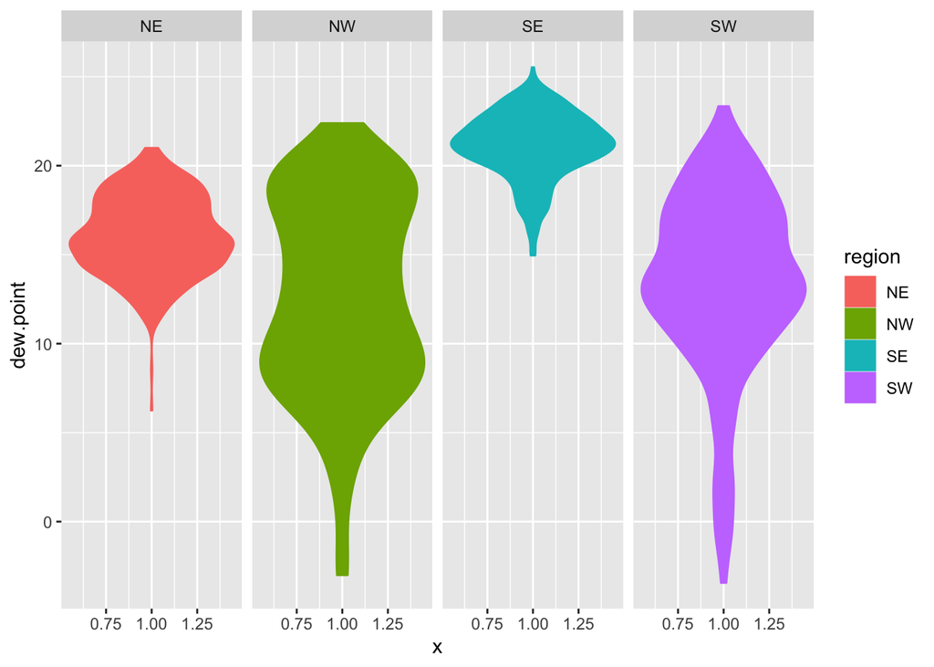

```r
met_avg[!is.na(region) & !is.na(dew.point)] %>%
  ggplot() +
  geom_violin(mapping = aes(x = 1, y =dew.point, color=region, fill = region)) +
  facet_wrap(~ region, nrow = 1)
```

4. Use geom_jitter with stat_smooth to examine the association between dew point temperature and wind speed by region

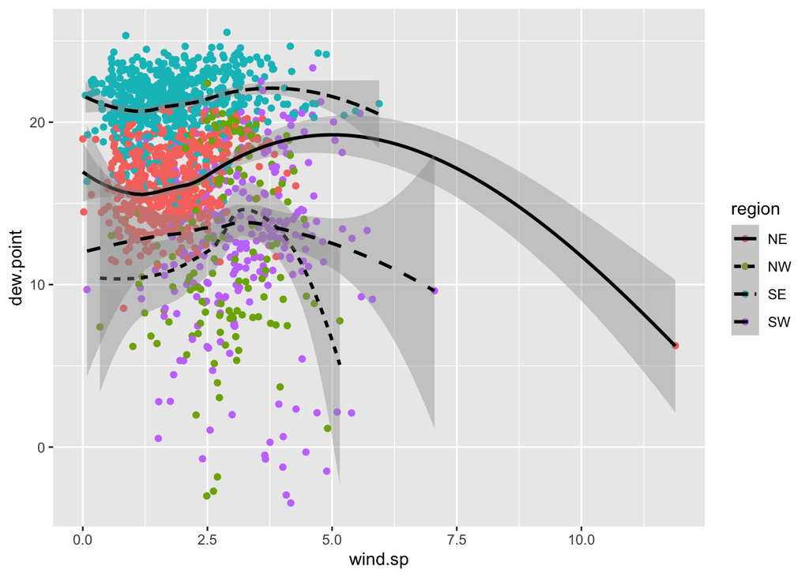

```r
met_avg[!is.na(region) & !is.na(dew.point) & !is.na(wind.sp)] %>%
  ggplot(mapping = aes(x = wind.sp, y =dew.point, color=region)) +
  geom_point(aes(color = region)) +
  geom_smooth(mapping = aes(linetype = region), color="black", formula = y ~ x, method = "loess")
```

5. Use geom_bar to create barplots of the weather stations by elevation category coloured by region

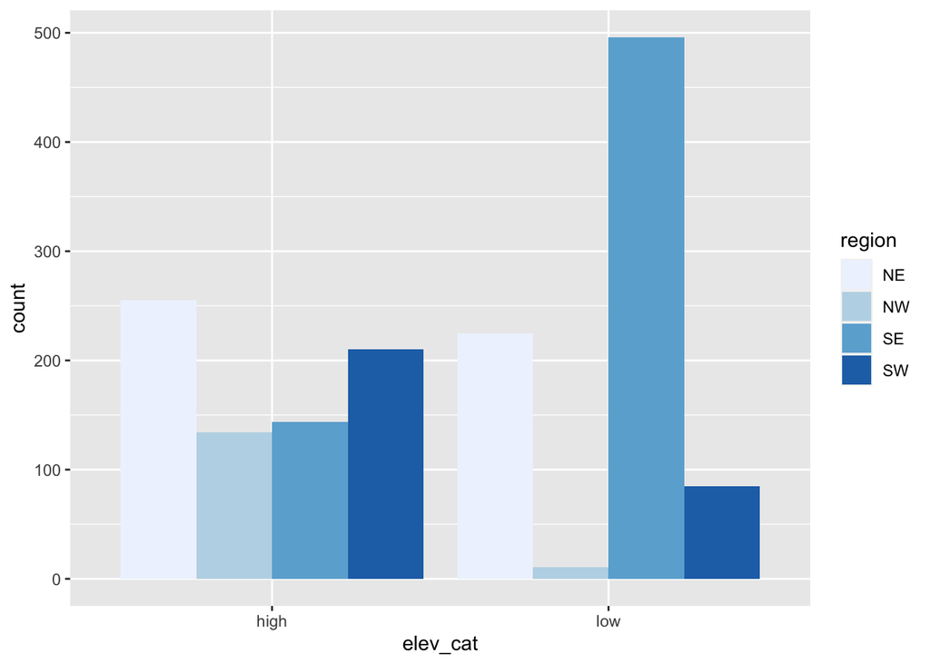

```r
met_avg[!is.na(region) & !is.na(dew.point) & !is.na(wind.sp)] %>%
  ggplot() +
  geom_bar(mapping = aes(x = elev_cat, fill = region), position = "dodge")+
  scale_fill_brewer(palette = "Blues")
```

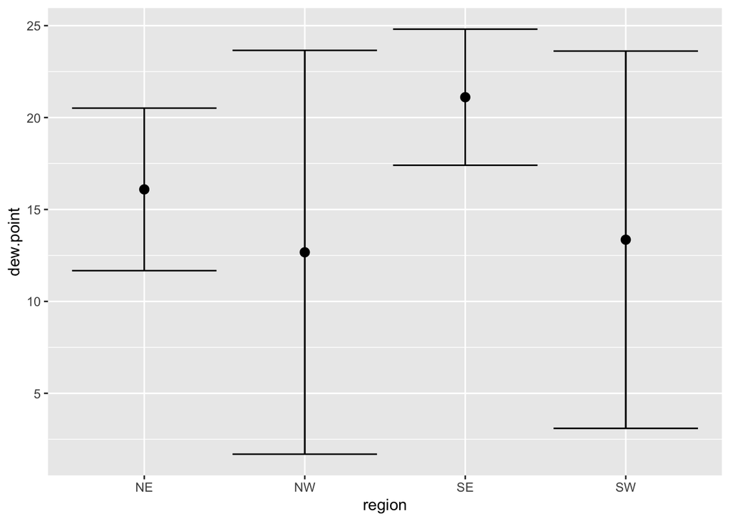

```r
met_avg[!is.na(region) & !is.na(dew.point) & !is.na(wind.sp)] %>%
  ggplot(mapping = aes(x = region, y = dew.point)) +
    stat_summary(fun.data = mean_sdl,
                 geom = "errorbar") +
    stat_summary(fun.data = mean_sdl)
```

7. Make a map showing the spatial trend in relative h in the US

```r
library(leaflet)
# Generating a color palette
rh.pal <- colorNumeric(c('darkgreen','goldenrod','brown'), domain=met_avg$rh)
rh.pal
```

[output not shown]

```r
met_top10 <- met_avg[rank(-rh) <= 10]
```

```r
rhmap <- leaflet(met_top10) %>%
  # The looks of the Map
  addProviderTiles('CartoDB.Positron') %>%
  # Some circles
  addCircles(
    lat = ~lat, lng=~lon,
                                                  # HERE IS OUR PAL!
    label = ~paste0(round(rh), ' C'), color = ~ rh.pal(rh),
    opacity = 1, fillOpacity = 1, radius = 500
    ) %>%
  # And a pretty legend
  addLegend('bottomleft', pal=rh.pal, values=met_avg$rh,
          title='Relative Humidity', opacity=1)

rhmap
```

[interactive chart not shown]